# Sistemos ggplot2 pagrindai

Facetės

```r
library(tidyverse)
knitr::opts_chunk$set(fig.height = 3, fig.width = 6)
Sys.setlocale(locale = "Lithuanian")
```

```
[1] "LC_COLLATE=Lithuanian_Lithuania.1257;LC_CTYPE=Lithuanian_Lithuania.1257;LC_MONETARY=Lithuanian_Lithuania.1257;LC_NUMERIC=C;LC_TIME=Lithuanian_Lithuania.1257"
```

# Facetės

## Funkcija facet_wrap()

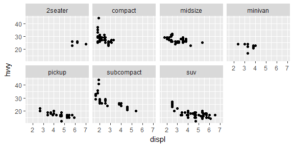

```r
ggplot(data = mpg) +
  geom_point(mapping = aes(x = displ, y = hwy)) +
  facet_wrap(~ class, nrow = 2)
```

## Funkcija facet_grid() - 1

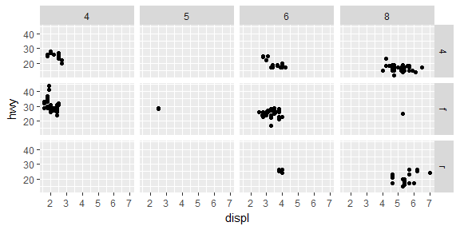

```r
ggplot(data = mpg) +
  geom_point(mapping = aes(x = displ, y = hwy)) +
  facet_grid(drv ~ cyl)
```

## Funkcija facet_grid() - 2

```r
t <- ggplot(mpg, aes(cty, hwy)) +
     geom_point()
```

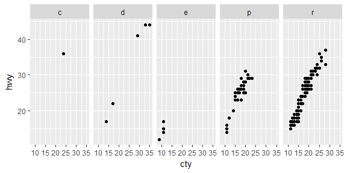

```r
t + facet_grid(. ~ fl)
```

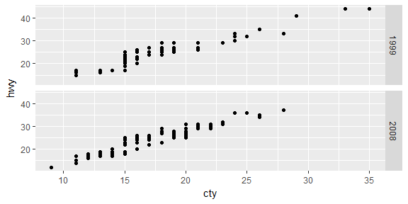

```r
t + facet_grid(year ~ .)
```

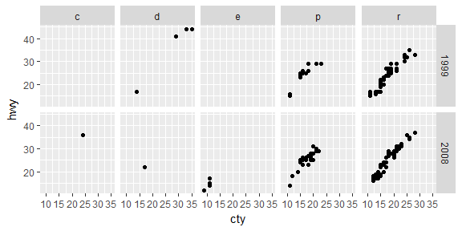

```r
t + facet_grid(year ~ fl)
```

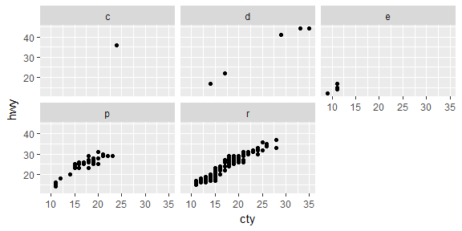

```r
t + facet_wrap(~ fl)
```

## Užduotys: facetės

1. Kas nutinka, jei facetes kuriame pagal tolydųjį kintamąjį?

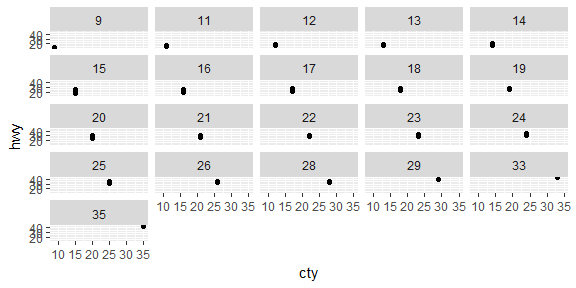

```r
t + facet_wrap(~ cty)
```

2. Ką rodo tušti langeliai įvykdžius funkciją `facet_grid(drv ~ cyl)`? Kaip jie susiję su šiuo grafiku:

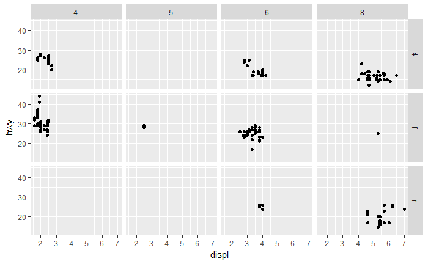

```r
ggplot(data = mpg) +
     geom_point(mapping = aes(x = displ, y = hwy)) +
  facet_grid(drv ~ cyl)
```

```r
#elementu atitinkanciu kintamuosius nera ( pvz 5 cilindru ir 4 varomuju ratu masinos mpg nera)
```

3. Ką daro žemiau pateiktas kodas? Ką reiškia taškas (`.`)?

```r
ggplot(data = mpg) +
    geom_point(mapping = aes(x = displ, y = hwy)) +
    facet_grid(drv ~ .)
#sukuria grafika kurio facetes padarytos pagal drv kintamaji. "." - dimensijoje nedaroma faceciu
```

[output not shown]

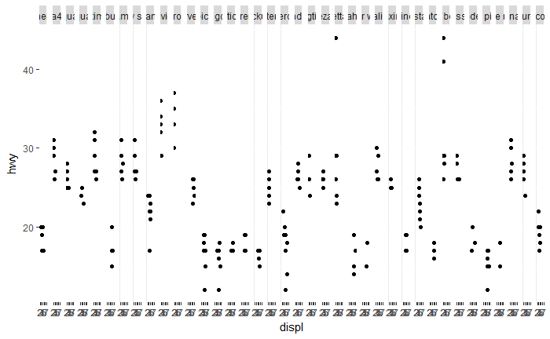

```r
ggplot(data = mpg) +
   geom_point(mapping = aes(x = displ, y = hwy)) +
   facet_grid(. ~ model)
```

4. Patyrinėkite antrąją grafiko facetę (kodas žemiau).
   1. Kokie privalumai naudoti facetes vs. išdėstymą spalvomis?
   2. Kokie trūkumai?
   3. Kaip balansas tarp privalumų ir trūkumų pakistų, jei turėtumėte žymiai daugiau duomenų? #a. - lengviau suprantami duomenys, nes mazesnis ju persidengimas #b. - sunkiau palyginti, nes duomenys skirtingose facetese #c. - kol nedaug faceciu, tol jos patogesnes, bet pasidaro sunkiua suprantamos, kai ju daug

```r
ggplot(data = mpg) +
    geom_point(mapping = aes(x = displ, y = hwy)) +
    facet_wrap(~ class, nrow = 2)
```

[output not shown]

Spalvomis išdėstykite klasių pavadinimus

```r
ggplot(data = mpg) +
    geom_point(mapping = aes(x = displ, y = hwy, color =  class)) +
    facet_wrap(~ class, nrow = 2)
```

[output not shown]

5. Perskaitykite funkcijos aprašymą: `?facet_wrap`.
   1. Kokią funkciją atlieka `nrow`? #faceciu eiluciu skaicius
   2. Kokią funkciją atlieka `ncol`? #faceciu stulpeliu skaicius
   3. Kurios kitos funkcijos kontroliuoja facečių išdėstymą? #as.table, dir
   4. Kodėl funkcija `facet_grid()` neturi parametrų `nrow` ir `ncol`? #nes sukuria facetes pagal kintamaji ir naudojami to kintamojo stulpeliai/eilutes
6. Kokiu atveju naudodami `facet_grid()` kintamąjį su didesniu kiekiu skirtingų reikšmių (faktoriaus lygių) turėtumėte atvaizduoti facečių stulpeliuose? Kodėl? #